# Funções e seus gráficos

```python
from cmath import *
from scipy import *
from matplotlib.pyplot import *
from math import *
from numpy import *
```

## Função afim

Uma função afim, ou função do primeiro grau, é uma função do tipo:

### f(x) = ax + b

Ou seja, uma função na qual a variável x está elevada à primeira potência.

O gráfico característico de uma função afim crescente é da forma:

```
Text(0.5,1,'Função Afim crescente')
```

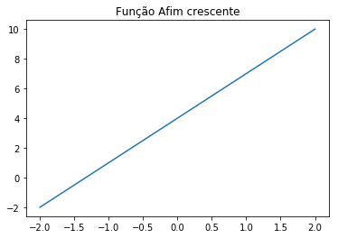

```python
x = linspace(-2,2,2)
plot(x,3*x+4)
title('Função Afim crescente')
```

Por outro lado, o gráfico de uma função afim decrescente é da forma:

```
Text(0.5,1,'Função Afim decrescente')
```

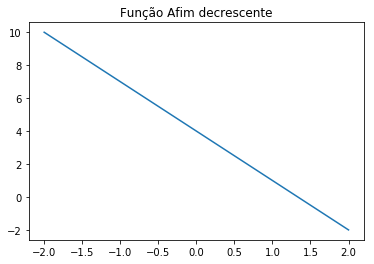

```python
x = linspace(-2,2,2)
plot(x,-3*x+4)
title('Função Afim decrescente')
```

## Função quadrática

Uma função quadrática, ou função do segundo grau, é uma função do tipo:

### f(x) = ax² + bx + c

Ou seja, uma função na qual a variável x está elevada à segunda potência.

O gráfico característico de uma função quadrática com a > 0 é da forma:

```
Text(0.5,1,'Função Quadrática com a > 0')
```

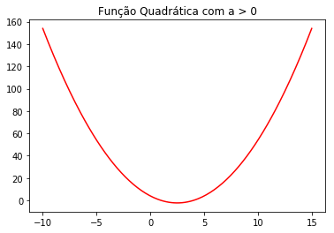

```python
x = linspace(-10,15,200)
plot(x,x**2-5*x+4, color="red")
title('Função Quadrática com a > 0')
```

Por outro lado, o gráfico de uma função quadrática com a < 0 é da forma:

```
Text(0.5,1,'Função Quadrática com a < 0')
```

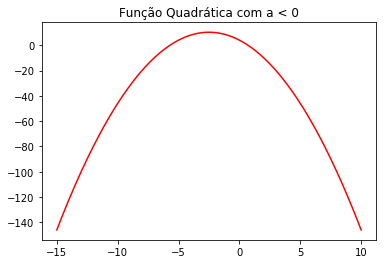

```python
x = linspace(-15,10,200)
plot(x,-x**2-5*x+4, color="red")
title('Função Quadrática com a < 0')
```

## Função cúbica

Uma função cúbica, ou função do terceiro grau, é uma função do tipo:

### f(x) = ax³ + bx² + cx + d

Ou seja, uma função na qual a variável x está elevada à terceira potência.

O gráfico característico de uma função cúbica é da forma:

```
Text(0.5,1,'Função Cúbica')
```

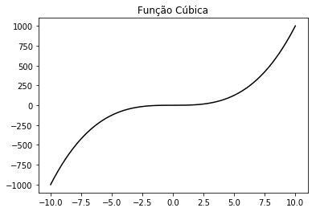

```python
x = linspace(-10,10,200)
plot(x,x**3, color="black")
title('Função Cúbica')
```

## Função exponencial

Uma função exponencial é uma função do tipo:

### f(x) = a<sup>x</sup>

Ou seja, uma função na qual a variável x está localizada na potência e na base está um número real.

O gráfico característico de uma função exponencial com x > 0 é da forma:

```
Text(0.5,1,'Função Exponencial com x > 0')
```

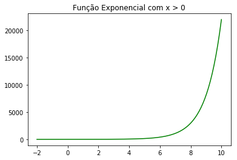

```python
x = linspace(-2,10,200)
plot(x,e**x, color="green")
title('Função Exponencial com x > 0')
```

Por outro lado, o gráfico de uma função exponencial com x < 0 é da forma:

```
Text(0.5,1,'Função Exponencial com x < 0')
```

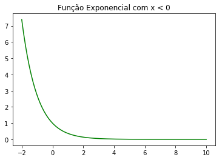

```python
x = linspace(-2,10,200)
plot(x,e**-x, color="green")
title('Função Exponencial com x < 0')
```

## Função logarítmica

O logaritmo de um número é definido como o expoente ao qual se deve elevar a base a para obter o número x. Uma função logarítmica é uma função do tipo:

### f(x) = log <sub>a</sub>x

O gráfico característico de uma função logarítmica positiva é da forma:

```
Text(0.5,1,'Função Logarítmica positiva')
```

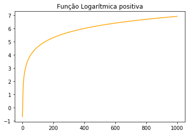

```python
x = linspace(0.5,1000,200)
plot(x,log (x), color="orange")
title('Função Logarítmica positiva')
```

Por outro lado, o gráfico de uma função logarítmica negativa é da forma:

```
Text(0.5,1,'Função Logarítmica negativa')
```

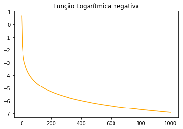

```python
x = linspace(0.5,1000,200)
plot(x,-log (x), color="orange")
title('Função Logarítmica negativa')
```

## Funções trigonométricas

Uma função trigonométrica é obtida através do auxílio do círculo trigonométrico.

### f(x) = sen x

```
Text(0.5,1,'Função Seno')
```

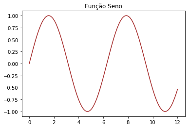

```python
x = linspace(0,12,200)
plot(x,sin(x), color="brown")
title('Função Seno')
```

### f(x) = cos x

```
Text(0.5,1,'Função Cosseno')
```

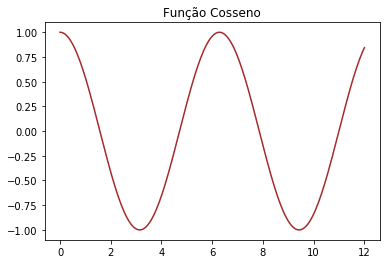

```python
x = linspace(0,12,200)
plot(x,cos(x), color="brown")
title('Função Cosseno')
```

### f(x) = tan x

```
Text(0.5,1,'Função Tangente')
```

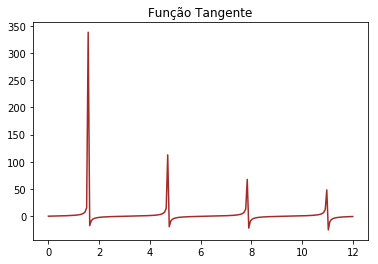

```python
x = linspace(0,12,200)
plot(x, tan(x), color="brown")
title('Função Tangente')
```

## Função modular

Uma função modular é uma função do tipo:

### f(x) = |x|

O gráfico característico de uma função modular positiva é da forma:

```
Text(0.5,1,'Função Modular positiva')
```

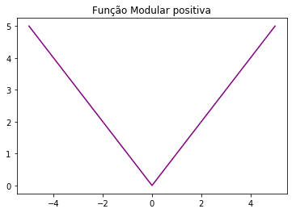

```python
x = linspace(-5,5,3)
plot(x, abs (x), color="purple")
title('Função Modular positiva')
```

Por outro lado, o gráfico de uma função modular negativa é da forma:

```
Text(0.5,1,'Função Modular negativa')
```

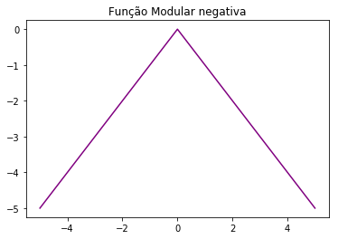

```python
x = linspace(-5,5,3)
plot(x, -abs (x), color="purple")
title('Função Modular negativa')
```